# DNA methylation analysis - HandsOn

8MEA16 - HT24

Shumaila Sayyab

# 1 BRIEF INTRODUCTION

## 1.1 DNA methylation

DNA methylation (DNAm) is an epigenetic mechanism that occurs by the addition of a methyl group to DNA. It can occur at different genome locations: gene bodies, promoter regions, or non-coding areas. The location of the methylation will often have an impact on gene regulation, modifying gene function and affecting gene expression. We will analyze a test data in RStudio using standard workflow pipeliens [minfi](https://www.ncbi.nlm.nih.gov/pmc/articles/PMC4016708/) and [ChAMP](https://academic.oup.com/bioinformatics/article/33/24/3982/4082274).

DNAm basic analysis follows a standard omic data analysis approach, which consists of several steps. From pre-processing of data and filtering (quality check, filtering poor quality probes/samples, chromosome X and Y, probes over SNPs and cross-reactive probes) to normalization, cell type deconvolution analysis, singular value decomposition analysis for confounder identification, correction of technical biases (batch effects) and identification of differentially methylated CpG sites (DMCs), genes (DMGs) or regions (DMRs). Finally the genes are mapped to the pathways to see the enrichment.

## 1.2 DATASET

To demonstrate the various aspects of analyzing DNA methylation data, we will be using a data, publicly available [PMID: 27942592](https://pubmed.ncbi.nlm.nih.gov/27942592/) Illumina Infinium array, 450k methylation dataset GSE85566. Genome-wide methylation data was generated from freshly isolated airway epithelial cells from 74 asthmatic and 41 nonasthmatic adults.

## 1.3 Data and Folder Hierarchy

All the material is under the directory /proj/liu-compute-2023-21/DNA_methylation

- **R_library**: Contains pre-installed R packages required for the analysis.
- **Lab_assignment4**: Includes raw data folder with `*.idat` files and the template `.Rmd` file.
- **Annotation**: Contains Illumina DNA methylation annotation files.
- **conda_env**: Contains the environment YAML file.

Please work in your own folder x_USERNAME (/proj/liu-compute-2023-21/users/x_USERNAME)

A recommendations is to crate a directory for this hands-on and have a good structure before starting. Here there is a suggestion which is also used in the tutorial below:

> /proj/liu-compute-2023-21/users/x_USERNAME/Lab_assignment4  
> /proj/liu-compute-2023-21/users/x_USERNAME/Lab_assignment4/Raw_data  
> /proj/liu-compute-2023-21/users/x_USERNAME/Lab_assignment4/Results  
> /proj/liu-compute-2023-21/users/x_USERNAME/Lab_assignment4/Results/Figures  
> /proj/liu-compute-2023-21/users/x_USERNAME/Lab_assignment4/Results/Tables

# 2 GETTING STARTED

## 2.1 LOGIN @ SIGMA

In this handson session, we will use **thinlinc** to do this analysis in **RStudio**. ONCE logged in via thinlinc, **OPEN TERMINAL** to copy the data for DNA methylation (DNAm) analysis.

MAKE SURE! to replace x_USERNAME to your own USER_ID throughout this tutorial.

### 2.1.1 Copy data

```bash
# NOTE!! replace x_USERNAME to your own user_id

# Change directory to your own directory
cd /proj/liu-compute-2023-21/users/x_USERNAME/

# Copy this data to your directory in /proj/liu-compute-2023-21/users/x_USERNAME
cp -r /proj/liu-compute-2023-21/DNA_methylation/Lab_assignment4/ .

# Change directory to lab_assignment and
cd Lab_assignment4/
```

- List the contents of Lab_assignment4 folder and see what files and folders you have?

### 2.1.2 Module load

Still in **TERMINAL**, type the following commands to load the modules.

```bash
module load R/4.4.0-hpc1-gcc-11.3.0-bare
module load RStudio/2023.09.1+494
rstudio
```

## 2.2 OPEN RSTUDIO

Open a template Rmarkdown script in **RStudio** and Setup the working and the **R_library** path as shown below.

- If there is a messege to upgrade the Rstudio version then press “remind later”

Setup working directory to your own USER folder

```r
# NOTE!! replace x_USERNAME to your own user_id

# Set working directory to your own directory
setwd("/proj/liu-compute-2023-21/users/x_USERNAME/Lab_assignment4")
```

Lets now create directories for results

```r
# Create directories for results
  new_dir = "Results"

  new_subdir <- c("Figures","Tables")

  for (dir in new_dir) {
    dir.create(path = paste0("", dir), showWarnings = FALSE)
  }
  for (dir in new_subdir) {
    dir.create(paste0("", "Results/", dir), showWarnings = FALSE)
  }

  rm(list = c("dir", "new_dir", "new_subdir"))
```

### 2.2.1 Load R_Libraries

Setup the path to R_library

```r
.libPaths("/proj/liu-compute-2023-21/DNA_methylation/R_library/")
.libPaths() # check if it has changed to path given above
```

Load the libraries for DNA methylation-Array data analysis.

```r
library("BiocManager")
library("ChAMP")
library("minfi")
library("limma")
library("RColorBrewer")
library("missMethyl")
library("minfiData")
library("Gviz")
library("DMRcate")
library("DMRcatedata")
library("stringr")
library("viridis")
library("gridExtra")
library("ggplot2")
library("reshape2")
library("tidyr")
library("EpiDISH")
library("ComplexHeatmap")
library("EnhancedVolcano")
library("DOSE")
library("ggrepel")
library("enrichplot")
library("clusterProfiler")
library("org.Hs.eg.db")
library("calibrate")
library("tidyverse")
library("patchwork")
library("cowplot")
library("IlluminaHumanMethylation450kanno.ilmn12.hg19")
library("IlluminaHumanMethylationEPICanno.ilm10b4.hg19")
library("rmarkdown")
library("ggpubr")
library("sva")
```

Set colors for the study groups

```r
# Setup colors for plotting
   col1=c("Asthma"="orange","Control"="royalblue")
```

## 2.3 LOAD ANNOTATIONS

Load Illumina annotations. Included with minfi is the *IlluminaHumanMethylation450kanno.ilmn12.hg19* package; it contains all the annotation information for each of the CpG probes on the 450k array. This will be useful later to to determine where the differentially methylated CpGs (hereafter referred to as DMCs) are located in a genomic context and to link the Red and Green raw data to methylated and unmethylated status.

**NOTE!** If you are working with EPIC array data, then you need to change the annotation to *IlluminaHumanMethylationEPICanno.ilm10b4.hg19*. For this hands-on we are working with 450k data.

```r
# get the 450k annotation data
    ann450k = getAnnotation(IlluminaHumanMethylation450kanno.ilmn12.hg19)

# if you have 850K or EPIC array, run the line below and use ann850k

    #ann850k = getAnnotation(IlluminaHumanMethylationEPICanno.ilm10b4.hg19)

# cleaned annotations using gene names and entrez IDs instead of using all 53 columns

    annot <- read.csv(file ="/proj/liu-compute-2023-21/DNA_methylation/Annotations/annotation.csv")

# List of Illumina cross reactive probes
    xReactiveProbes <- read.table("/proj/liu-compute-2023-21/DNA_methylation/Annotations/48639-non-specific-probes-Illumina450k.csv",sep=",",header=T)
```

Inspect the top few lines of Illumina annotations.

```r
  head(annot)
```

```
##       CpG_ID Relation_to_Island Gene_Symbol         Gene_Accession
## 1 cg18478105             Island      YTHDF1              NM_017798
## 2 cg09835024             Island      EIF2S3              NM_001415
## 3 cg14361672            N_Shore        PKN3              NM_013355
## 4 cg01763666            OpenSea      CCDC57              NM_198082
## 5 cg12950382            OpenSea        INF2 NM_022489;NM_001031714
## 6 cg02115394             Island       CDC16 NM_003903;NM_001078645
##      Gene_Group Entrez_ID
## 1        TSS200     54915
## 2       TSS1500      1968
## 3       TSS1500     29941
## 4          Body    284001
## 5     Body;Body     64423
## 6 TSS200;TSS200      8881
```

Question 1: Can you tell, what is the name of column with CpG_id and gene information in ann450k dataframe ?

## 2.4 IMPORT RAW DATA

We will import and read the raw data intensity files (IDAT) with minfi package. The dataset *Raw_data* have been provided to you in your Lab_assignment4 folder already, so you just need to point R towards the directory path they are saved.

- *list.files* function will return the list of files in the specified directory.
- *read.metharray.sheet* function, takes the path to rawdata and samplesheet. The samplesheet is a CSV (comma-separated) file containing one line per sample, with a number of columns describing each sample.
- *read.metharray.exp* function create a column called Basename which specifies the location of each individual IDAT file in the experiment.  
  This generates an RGChannelSet object containing the raw green and red intensity data.

```r
# set the data directory
  dataDirectory <- "Raw_data"
# list the files
  #list.files(dataDirectory, recursive = TRUE)

# read in the sample sheet for the experiment
  targets <- read.metharray.sheet(dataDirectory, pattern="Demographic_data_Asthma.csv")
```

```
## [1] "Raw_data/Demographic_data_Asthma.csv"
```

```r
# read in the raw data from the IDAT files; warnings can be ignored.
  rgSet <- read.metharray.exp(targets=targets)

# Get an overview of the raw data i.e. rgSet
  rgSet
```

```
## class: RGChannelSet
## dim: 622399 115
## metadata(0):
## assays(2): Green Red
## rownames(622399): 10600313 10600322 ... 74810490 74810492
## rowData names(0):
## colnames(115): GSM2277328_9904796063_R03C01
##   GSM2277252_7973201092_R02C02 ... GSM2277224_7973201017_R03C02
##   GSM2277287_9904796042_R03C01
## colData names(13): Sample_Name ID ... Basename filenames
## Annotation
##   array: IlluminaHumanMethylation450k
##   annotation: ilmn12.hg19
```

```r
# Get the overview of Illumina array design
  getManifest(rgSet)
```

```
## IlluminaMethylationManifest object
## Annotation
##   array: IlluminaHumanMethylation450k
## Number of type I probes: 135476
## Number of type II probes: 350036
## Number of control probes: 850
## Number of SNP type I probes: 25
## Number of SNP type II probes: 40
```

```r
# change the names of the samples into something a little more descriptive and meaningful
  targets$ID <- paste(targets$Sample_Name,targets$Sample_Group,sep=".")
  sampleNames(rgSet) <- targets$ID

## save the target information in sample variable
  samples<-targets
  head(samples)
```

```
##   Sample_Name                ID Sample_Group Gender Age Ethnicity
## 1   02d9_41bc  02d9_41bc.Asthma       Asthma Female  39        EA
## 2   0447_47e4  0447_47e4.Asthma       Asthma Female  31        AA
## 3   0607_495d  0607_495d.Asthma       Asthma Female  28        AA
## 4   06f5_4503  06f5_4503.Asthma       Asthma Female  37        AA
## 5   07f4_4e79  07f4_4e79.Asthma       Asthma   Male  30        AA
## 6   0a57_4360 0a57_4360.Control      Control   Male  37        AA
##   current_smoker Smoke_Ever smoke_pack_years_1  Array      Slide
## 1              N          Y                  3 R03C01 9904796063
## 2              Y          Y               0.85 R02C02 7973201092
## 3              N          N                  0 R04C01 7973201092
## 4              N          N                  0 R05C02 9904796042
## 5              N          N                  0 R03C01 7973201092
## 6              N          N                  0 R06C02 7973201092
##                                Basename
## 1 Raw_data/GSM2277328_9904796063_R03C01
## 2 Raw_data/GSM2277252_7973201092_R02C02
## 3 Raw_data/GSM2277255_7973201092_R04C01
## 4 Raw_data/GSM2277291_9904796042_R05C02
## 5 Raw_data/GSM2277253_7973201092_R03C01
## 6 Raw_data/GSM2277260_7973201092_R06C02
```

```r
# Here we save the raw rgSet object that can be used later ..
#save(rgSet,file = "rgSet_Asthma.RData")
```

Check the demographic information about the study in the “samples” variable, such as age, sex, smoking etc.

## 2.5 PREPROCESSING

Let us now transform RGChannelSet object to MethylSet object containing the methylated and unmethylated signals. We will use function *preprocessRaw* which uses the array design to match up the different probes and color channels to construct the methylated and unmethylated signals. No normalization is performed yet. As we will see in a later section #7, there are several normalization options that automatically take care of the preprocessing and conversion of a RGChannelSet object to a GenomicRatioSet object.

```r
  MSet <- preprocessRaw(rgSet)
  MSet
```

```
## class: MethylSet
## dim: 485512 115
## metadata(0):
## assays(2): Meth Unmeth
## rownames(485512): cg00050873 cg00212031 ... ch.22.47579720R
##   ch.22.48274842R
## rowData names(0):
## colnames(115): 02d9_41bc.Asthma 0447_47e4.Asthma ... ff13_4c84.Asthma
##   fff9_43b1.Asthma
## colData names(13): Sample_Name ID ... Basename filenames
## Annotation
##   array: IlluminaHumanMethylation450k
##   annotation: ilmn12.hg19
## Preprocessing
##   Method: Raw (no normalization or bg correction)
##   minfi version: 1.52.0
##   Manifest version: 0.4.0
```

```r
# Compare to previous object
  rgSet
```

```
## class: RGChannelSet
## dim: 622399 115
## metadata(0):
## assays(2): Green Red
## rownames(622399): 10600313 10600322 ... 74810490 74810492
## rowData names(0):
## colnames(115): 02d9_41bc.Asthma 0447_47e4.Asthma ... ff13_4c84.Asthma
##   fff9_43b1.Asthma
## colData names(13): Sample_Name ID ... Basename filenames
## Annotation
##   array: IlluminaHumanMethylation450k
##   annotation: ilmn12.hg19
```

```r
  head(getMeth(MSet)[,1:14])
```

```
##            02d9_41bc.Asthma 0447_47e4.Asthma 0607_495d.Asthma 06f5_4503.Asthma
## cg00050873              365              494              478              522
## cg00212031              233              316              562              448
## cg00213748              366              442              623              444
## cg00214611              310              431              596              498
## cg00455876              306              503              664              560
## cg01707559              786             1028             1440              825
##            07f4_4e79.Asthma 0a57_4360.Control 0d7e_4fec.Asthma 0e79_441c.Asthma
## cg00050873            23502             24450            17892            20662
## cg00212031              550               478              310              457
## cg00213748             4209              3937             2372             2888
## cg00214611              658               667              297              581
## cg00455876             7005              6148             5215             5103
## cg01707559             1342              1237              790              927
##            107e_4776.Asthma 1299_419b.Asthma 12b2_42c4.Control
## cg00050873            19253              313               681
## cg00212031              657              291               487
## cg00213748             3011              270               569
## cg00214611              388              278               575
## cg00455876             5233              246               608
## cg01707559              612              464              1233
##            154f_455f.Control 1586_4591.Control 15e4_4e17.Asthma
## cg00050873             14572               264              638
## cg00212031               297               208              683
## cg00213748              2682               248              651
## cg00214611               266               192              653
## cg00455876              4231               302              711
## cg01707559               642               443             1651
```

```r
  head(getUnmeth(MSet)[,1:3])
```

```
##            02d9_41bc.Asthma 0447_47e4.Asthma 0607_495d.Asthma
## cg00050873              320              553              556
## cg00212031              283              434              579
## cg00213748              306              559              587
## cg00214611              261              339              613
## cg00455876              936              836             1107
## cg01707559              803             1550             1621
```

Question 2: When you transform RGChannelSet object to MethylSet object, notice that the red and green assays have been transformed in Meth and Unmeth signals. Compare both the objects (rgSet and MSet). what differences did you noticed ?

### 2.5.1 Quality Control

An important step before normalization is Quality Control.TThe functions *getQC* and *plotQC* are designed to extract and plot the quality control information from the MethylSet. In the resulting plot, the line separating ”bad” from ”good” samples represent a useful cutoff, which is not always very clear and may have to be adapted to a specific dataset.

QCplot

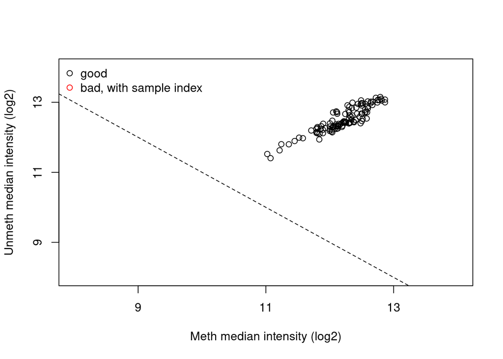

```r
    qc <- getQC(MSet)
    plotQC(qc)
```

Density plot of Raw methylation data

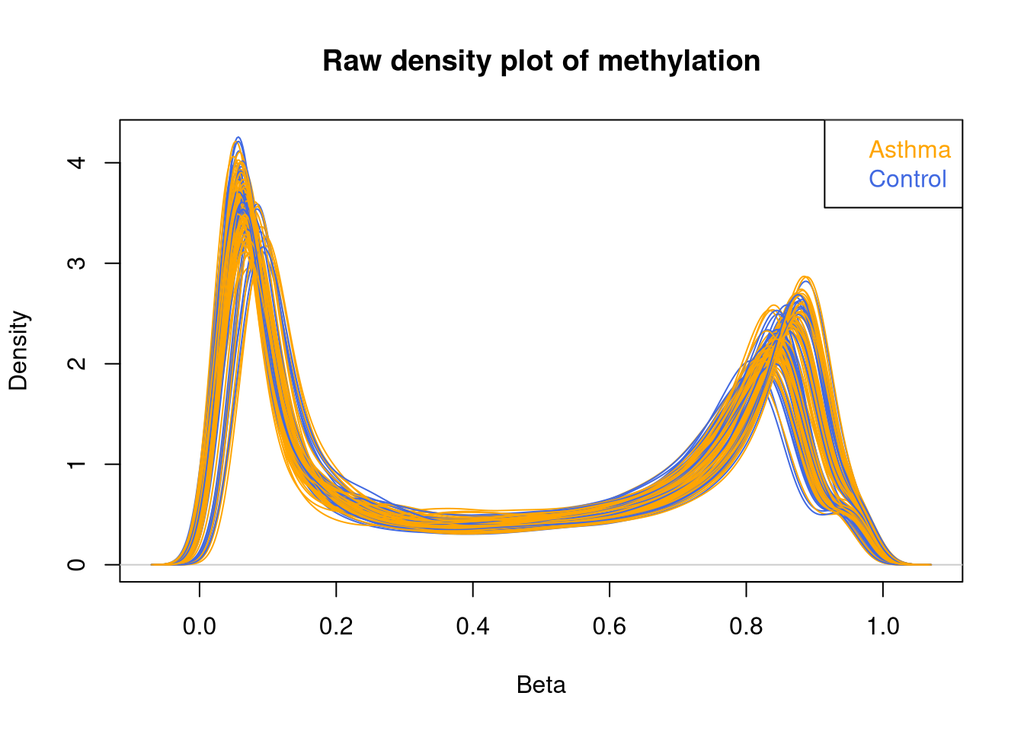

```r
# Check the density plot distribution of raw MethylSet object
densityPlot(MSet, sampGroups = MSet$Sample_Group,pal = col1, main= "Raw density plot of methylation")
```

### 2.5.2 DetectionP

The function *detectionP* calculate detection p-values. We can generate a detection p-value for every CpG in every sample, which is indicative of the quality of the signal. The method used by minfi to calculate detection p-values compares the total signal (M + U) for each probe to the background signal level, which is estimated from the negative control probes. Very small p-values are indicative of a reliable signal while large p-values, for example >0.01, generally indicate a poor quality signal.

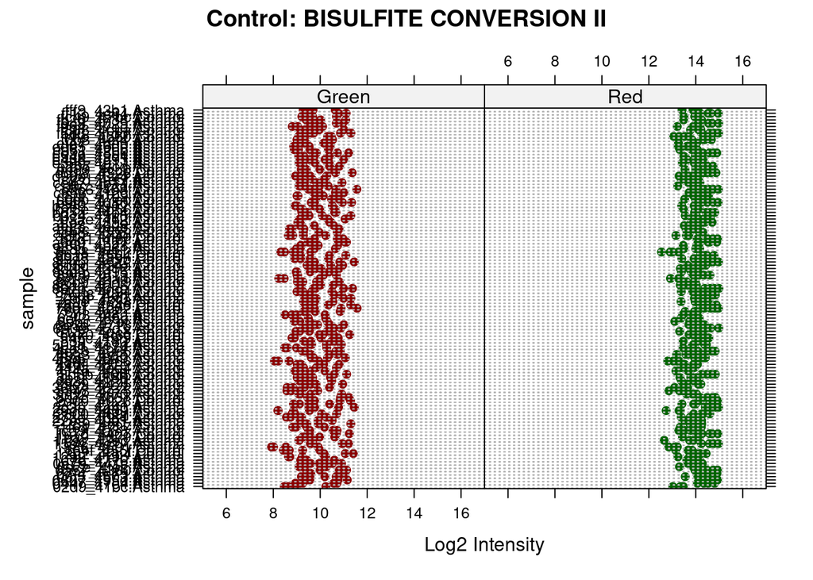

```r
  detP <- detectionP(rgSet)

# This will plot the control probe signals. Read more at '?controlStripPlot'
  controlStripPlot(rgSet, controls="BISULFITE CONVERSION II")
```

Plotting the mean detection p-value for each sample allows us to gauge the general quality of the samples in terms of the overall signal reliability. Samples that have many failed probes will have relatively large mean detection p-values.

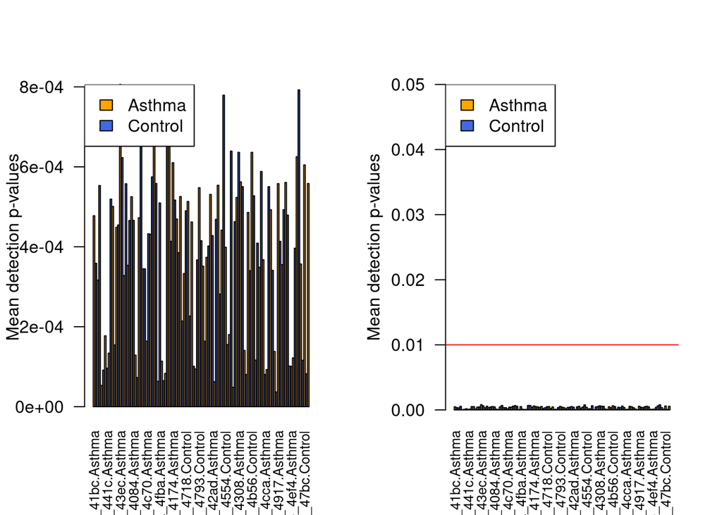

```r
# examine mean detection p-values across all samples to identify any failed samples
  pal <- col1
  par(mfrow=c(1,2))
  barplot(colMeans(detP), col=col1, las=2,
           cex.names=0.8,ylab="Mean detection p-values")
  abline(h=0.01,col="red")
  legend("topleft", legend=levels(factor(targets$Sample_Group)), fill=pal,
          bg="white")

  barplot(colMeans(detP), col=col1, las=2,
           cex.names=0.8, ylim = c(0,0.05), ylab="Mean detection p-values")
  abline(h=0.01,col="red")
  legend("topleft", legend=levels(factor(targets$Sample_Group)), fill=pal,
          bg="white")
```

Question 3: After checking the Quality control  
- 1. How many samples are bad in your dataset based on plotQC?  
- 2. Was there any failed sample based on large mean detection p-values?

Based on the above observations, it is important to remove any poor quality samples. These samples can be easily excluded from the analysis using a detection p-value cutoff of 0.05.

```r
# remove poor quality samples
  keep <- colMeans(detP) < 0.05
  rgSet <- rgSet[,keep]
  table(keep)
```

```
## keep
## TRUE
##  115
```

```r
# remove poor quality samples from targets data
  samples <- samples[keep,]
  dim(samples)
```

```
## [1] 115  12
```

```r
  samples[1:5,1:5]
```

```
##   Sample_Name               ID Sample_Group Gender Age
## 1   02d9_41bc 02d9_41bc.Asthma       Asthma Female  39
## 2   0447_47e4 0447_47e4.Asthma       Asthma Female  31
## 3   0607_495d 0607_495d.Asthma       Asthma Female  28
## 4   06f5_4503 06f5_4503.Asthma       Asthma Female  37
## 5   07f4_4e79 07f4_4e79.Asthma       Asthma   Male  30
```

```r
# remove poor quality samples from detection p-value table
  detP <- detP[,keep]
  table(keep)
```

```
## keep
## TRUE
##  115
```

## 2.6 NORMALIZATION

To minimise the unwanted variation within and between samples, various data normalisations can be applied. Many different types of normalisation have been developed for methylation arrays which are available in minfi. An important question is to decide which one is best or most optimal for your particular dataset. Here is a short summary of each method:

*preprocessRaw*: Converts a RGChannelSet to a MethylSet by converting the Red and Green channels into a matrix of methylated signals and a matrix of unmethylated signals. No normalization is performed.

*preprocessIllumina*: Convert a RGChannelSet to a MethylSet by implementing the preprocessing choices as available in Genome Studio: background subtraction and control normalization. Both of them are optional and turning them off is equivalent to raw preprocessing.

*preprocessSWAN*: Perform Subset-quantile within array normalization [SWAN](https://genomebiology.biomedcentral.com/articles/10.1186/gb-2012-13-6-r44), a within-array normalization correction for the technical differences between the Type I and Type II array designs.

**NOTE!** It is recommended in case of global biological methylation differences between your samples for example dataset with cancer and normal samples, or a dataset with different tissues/cell types, use the *preprocessFunnorm* [Funnorm](https://genomebiology.biomedcentral.com/articles/10.1186/s13059-014-0503-2) function. While incases where you do not expect global differences between your samples, for instance a blood dataset, or one-tissue dataset, use the *preprocessQuantile* [Quantile](https://pubmed.ncbi.nlm.nih.gov/22690668/) normalization function.

```r
  # normalize the data; this results in a GenomicRatioSet object
    mSetSw <- preprocessSWAN(rgSet)
```

Density Plot after Normalization

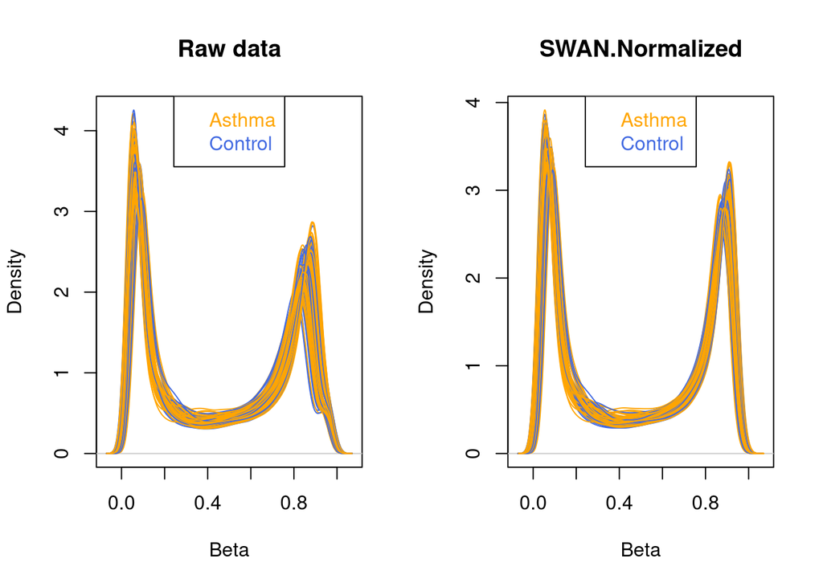

```r
# Visualise what the data looks like before and after normalization

#Density plot
par(mfrow=c(1,2))
    densityPlot(rgSet, sampGroups=samples$Sample_Group,main="Raw data", legend=FALSE,pal = col1)
    legend("top", legend = levels(factor(samples$Sample_Group)),
           text.col=col1)
    densityPlot(getBeta(mSetSw), sampGroups=samples$Sample_Group,
                main="SWAN.Normalized", legend=FALSE,pal=col1)
    legend("top", legend = levels(factor(samples$Sample_Group)),
           text.col=col1)
```

Question 4: In this dataset, we are comparing Asthama and Control samples, which normalization method you think would be optimal for our dataset?

### 2.6.1 MDS plot

Now we will visualaize the data using Multidimensional scaling (MDS) plot. The plot shows the controls and Asthma patient samples showing the distances between the samples using the top 1000 most variable CpG positions. The distances are calculated using Eucledian distance matrix.

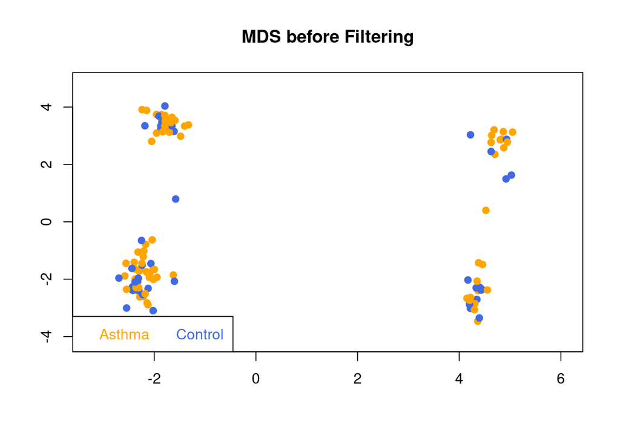

```r
## Data exploration- MDS plot showing dimension1 and dimension2
mdsPlot(getBeta(mSetSw), numPositions = 1000, sampNames = NULL, sampGroups = samples$Sample_Group,
            pch = 19, pal = col1, legendPos = "bottomleft",
            main = "MDS before Filtering")
```

Question 5: Plot MDS of the beta values before filtering and change *sampNames = NULL* to *sampNames = samples$Gender*. Did you see any clusters due to gender bias or any other covariate?

## 2.7 FILTERING

Poor performing probes are generally filtered out before differential methylation analysis. By removing them we perform fewer statistical tests and reduced multiple testing penalty. Following probes are filtered away:

- Probes that have failed in one or more samples based on detection p-value.
- Depending on the nature of your samples and your biological question you may also choose to filter out the probes from the X and Y chromosomes
- Probes that are known to have common SNPs at the CpG site
- Probes that are cross-reactive.

```r
# ensure probes are in the same order in the mSetSw and detP objects
    detP <- detP[match(featureNames(mSetSw),rownames(detP)),]

#1 remove any probes that have failed in one or more samples; this next line
    keep <- rowSums(detP < 0.01) == ncol(mSetSw)
    table(keep)
```

```
## keep
##  FALSE   TRUE
##   3647 481865
```

```r
    # Subset the GenomicRatioSet
    mSetSwFlt.bf <- mSetSw[keep,]
    # mSetSwFlt.bf contains the probes before X and Y filtering
    dim(mSetSwFlt.bf)
```

```
## [1] 481865    115
```

```r
#2 if your data includes males and females, remove probes on the sex chromosomes
    keep <- !(featureNames(mSetSwFlt.bf) %in% ann450k$Name[ann450k$chr %in%
                                                                   c("chrX","chrY")])
    table(keep)
```

```
## keep
##  FALSE   TRUE
##  11175 470690
```

```r
    mSetSwFlt <- mSetSwFlt.bf[keep,]
    dim(mSetSwFlt)
```

```
## [1] 470690    115
```

```r
#3 remove probes with SNPs at CpG site
    gset <- mapToGenome(mSetSwFlt)
    mSetSwFlt <- dropLociWithSnps(gset)
    dim(mSetSwFlt)
```

```
## [1] 454707    115
```

```r
    dim(samples)
```

```
## [1] 115  12
```

```r
#4 exclude cross reactive probes

    keep <- !(featureNames(mSetSwFlt) %in% xReactiveProbes$TargetID )
    table(keep)
```

```
## keep
##  FALSE   TRUE
##  26453 428254
```

```r
    mSetSwFlt <- mSetSwFlt[keep,]
    #After removing the xReactiveProbes=cross reactive probes or multihit probes.
    dim(mSetSwFlt)
```

```
## [1] 428254    115
```

Question 6: Can you see why SNP can be a problem in methylation data analysis (Hint: C to T conversions are the most common type of SNP in the human genome)?

Question 7: How many probes were filtered due to (i) failure in one or more samples based on detection p-value. (ii) X and Y chromosomes (iii) common SNPs at the CpG site and (iv) cross-reactive probes.

## 2.8 BETA Values and M-values

Beta-value represents the ratio of the methylated probe intensity to the overall intensity. It is commonly used to quantify the level of methylation at a specific CpG site. Beta value range from 0 (unmethylated) to 1 (fully methylated).

- Beta = M/(M + U + 100)
- Mvalue = log2(M/U)

```r
# Calculation of M values and beta values
    mVals <- getM(mSetSwFlt)
    bVals <- getBeta(mSetSwFlt)
    head(bVals[,1:5])
```

```
##            02d9_41bc.Asthma 0447_47e4.Asthma 0607_495d.Asthma 06f5_4503.Asthma
## cg13869341       0.79115504       0.73056878       0.75805947       0.86317311
## cg24669183       0.71568831       0.81785450       0.77312724       0.81078321
## cg15560884       0.62025516       0.63537529       0.65466151       0.71159003
## cg01014490       0.04529649       0.03922893       0.04366716       0.04402716
## cg17505339       0.90573133       0.90258599       0.90015848       0.93056473
## cg11954957       0.77826087       0.78752207       0.79746968       0.83275351
##            07f4_4e79.Asthma
## cg13869341       0.79119159
## cg24669183       0.74002199
## cg15560884       0.65370633
## cg01014490       0.03750207
## cg17505339       0.90883371
## cg11954957       0.78998768
```

```r
    head(mVals[,1:5])
```

```
##            02d9_41bc.Asthma 0447_47e4.Asthma 0607_495d.Asthma 06f5_4503.Asthma
## cg13869341        1.9215281        1.4391031        1.6476585         2.657298
## cg24669183        1.3318580        2.1667529        1.7688224         2.099276
## cg15560884        0.7078315        0.8011966        0.9227381         1.302925
## cg01014490       -4.3975818       -4.6142027       -4.4528920        -4.440504
## cg17505339        3.2642328        3.2118632        3.1724672         3.744366
## cg11954957        1.8113904        1.8900074        1.9772918         2.315914
##            07f4_4e79.Asthma
## cg13869341        1.9218472
## cg24669183        1.5091785
## cg15560884        0.9166466
## cg01014490       -4.6817412
## cg17505339        3.3174440
## cg11954957        1.9113562
```

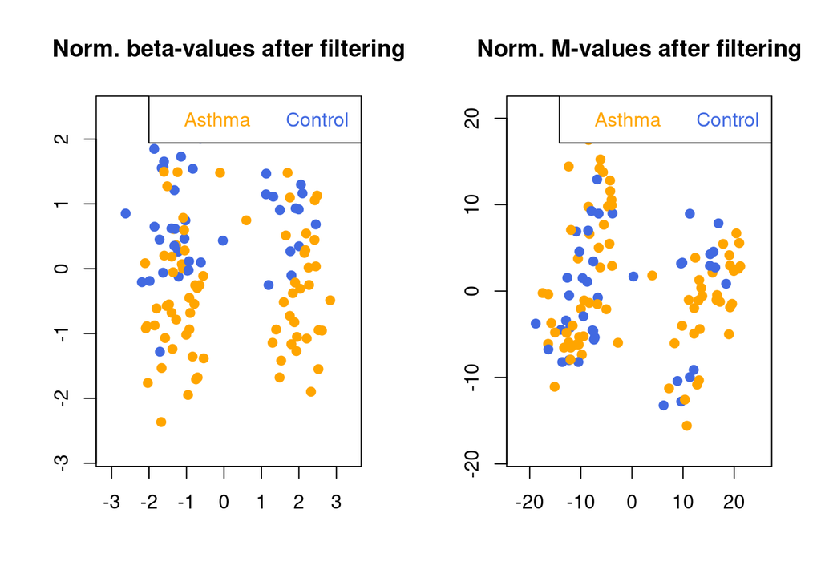

```r
# MDS plot after applying all the filtering
    par(mfrow=c(1,2))
    mdsPlot(dat =bVals , numPositions = 1000, sampNames = NULL, sampGroups = samples$Sample_Group,
                pch = 19, pal = col1,
                legendPos ="topright",
                main = "Norm. beta-values after filtering")
    mdsPlot(dat =mVals , numPositions = 1000, sampNames = NULL, sampGroups = samples$Sample_Group,
                pch = 19, pal = col1,
                legendPos ="topright",
                main = "Norm. M-values after filtering")
```

## 2.9 SINGULAR VALUE DECOMPOSITION

Singular value decomposition (SVD) analyses is performed to identify major sources of variation using the ChAMP package *champ.SVD* function. Analyses on the filtered and normalized beta matrix are performed.

Any confounding components that contributed to significant variation within the data set is identified using SVD. You get two plots as a result of the champ.SVD

- Scree-plot: shows Percent variance explained by each component
- Heatmap of SVD: shows the variables (age, sex, slide, array etc.) explaining significant variance (darker the color, more significant variance explained).

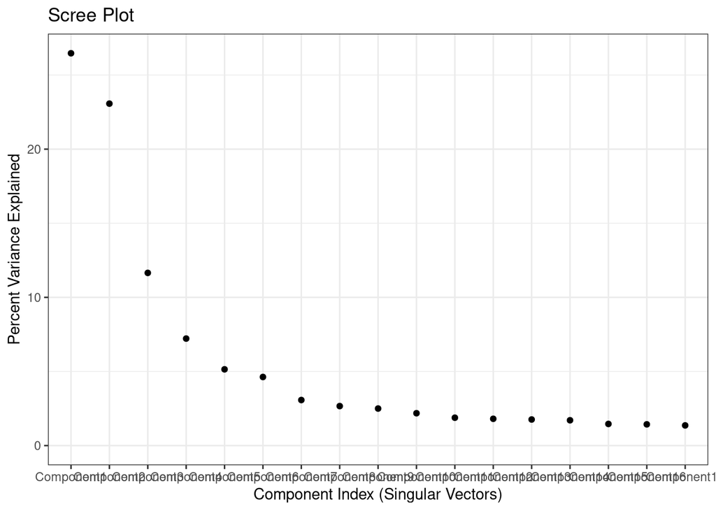

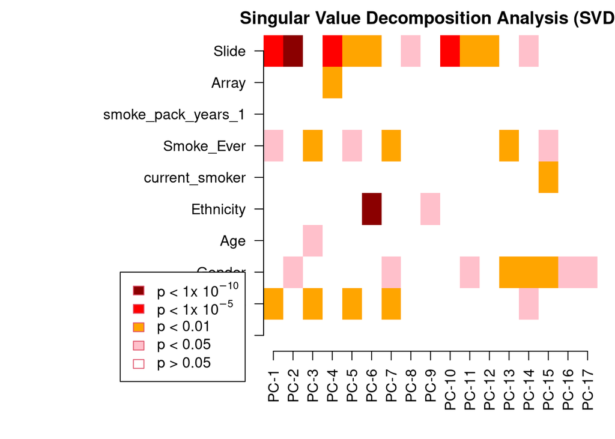

```
##              ID Sample_Group       Gender        Age    Ethnicity
##  [1,] 0.4823846 0.0029014038 9.423049e-01 0.80464063 1.388810e-01
##  [2,] 0.4823846 0.4477946200 3.914707e-02 0.86086873 8.510906e-02
##  [3,] 0.4823846 0.0001006948 1.865641e-01 0.02071567 9.114513e-01
##  [4,] 0.4823846 0.9209266667 4.086559e-01 0.62264963 7.227824e-01
##  [5,] 0.4823846 0.0029571624 5.286961e-02 0.61266211 5.363694e-01
##  [6,] 0.4823846 0.3180348680 8.328181e-01 0.66567649 1.638062e-18
##  [7,] 0.4823846 0.0005585734 4.998307e-02 0.07188162 5.215032e-01
##  [8,] 0.4823846 0.1811644410 5.825598e-02 0.81232675 1.611134e-01
##  [9,] 0.4823846 0.1508758075 9.327102e-01 0.29483447 2.669634e-02
## [10,] 0.4823846 0.5359454128 8.422421e-01 0.80892800 6.463811e-01
## [11,] 0.4823846 0.7747853541 1.558581e-02 0.82968824 3.426581e-01
## [12,] 0.4823846 0.9302040617 1.845606e-01 0.41574231 1.089651e-01
## [13,] 0.4823846 0.8931639684 1.079823e-03 0.47441214 2.336073e-01
## [14,] 0.4823846 0.0260988513 7.418906e-05 0.39675487 7.066357e-01
```

[output cut: 21 more lines]

```r
# Select PD file covariates to analyze
    samples_svd <- samples
    samples_svd [] <- lapply(samples_svd, as.character) # set all variables to character


# SVD before correction
    champ.SVD(beta=as.data.frame(bVals),pd=samples_svd,Rplot = TRUE,resultsDir = "Results/Figures/")
```

## 2.10 BATCH EFFECT CORRECTION

Based on SVD, corrections are performed for the identified components using *Combat* from the SVA package. This allows us to identify any technical bias in data and correct for any batch affects or confounders.

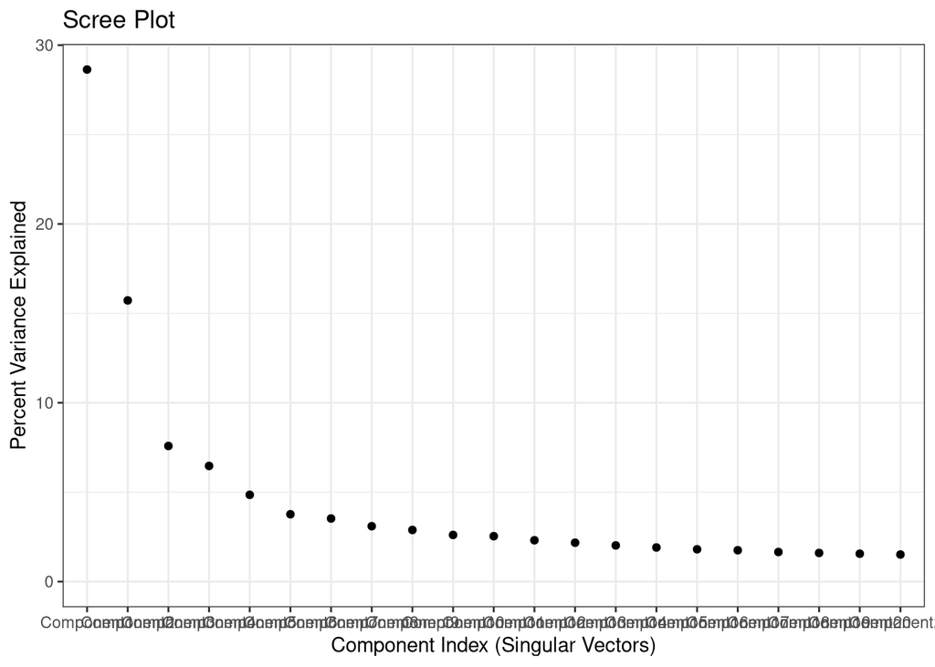

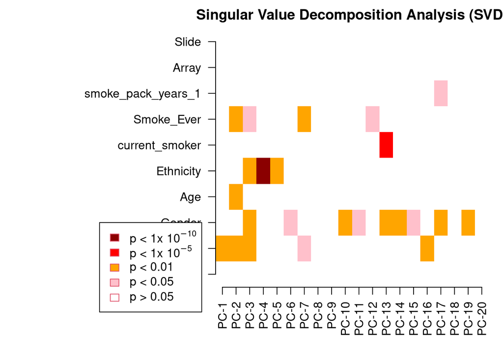

```
##              ID Sample_Group       Gender         Age    Ethnicity
##  [1,] 0.4823846 0.0006777672 5.748707e-01 0.903401488 4.805814e-01
##  [2,] 0.4823846 0.0023483502 9.087693e-01 0.008471412 8.439266e-01
##  [3,] 0.4823846 0.0063930576 1.636141e-04 0.383264009 3.433686e-03
##  [4,] 0.4823846 0.6656677993 5.872679e-01 0.718725350 5.143959e-13
##  [5,] 0.4823846 0.0633299799 8.564201e-01 0.561746509 3.822062e-03
##  [6,] 0.4823846 0.1699969695 1.170213e-02 0.486016227 3.656205e-01
##  [7,] 0.4823846 0.0166623549 8.944431e-01 0.833901781 7.293989e-02
##  [8,] 0.4823846 0.6956295700 5.956009e-01 0.383264009 6.274906e-02
##  [9,] 0.4823846 0.5436667779 3.109525e-01 0.942902480 6.586424e-01
## [10,] 0.4823846 0.5056223404 4.764239e-03 0.476244362 9.759378e-01
## [11,] 0.4823846 0.9394909511 2.771104e-02 0.927432559 4.105701e-01
## [12,] 0.4823846 0.1246091948 1.747817e-01 0.179011628 1.383781e-01
## [13,] 0.4823846 0.8107896383 2.141792e-03 0.065347864 8.396932e-01
## [14,] 0.4823846 0.6956295700 5.531929e-03 0.867138914 3.323304e-01
```

[output cut: 27 more lines]

```r
# Batch correction on beta-values
    batchname <- c("Slide", "Array")
        beta_corr <- bVals ## giving the normalized beta matrix only
        for (batchvar in batchname){
          beta_corr <- ComBat(
            dat=beta_corr,
            batch=samples[, batchvar],
            mod = NULL, ## this is where we donot give the variable of interest
          )
        }
        bVals.corrected <- beta_corr
# Batch correction on M-values
    batchname <- c("Slide", "Array")
        MVal_corr <- mVals ## giving the normalized beta matrix only
        for (batchvar in batchname){
          MVal_corr <- ComBat(
            dat=MVal_corr,
            batch=samples[, batchvar],
            mod = NULL, ## this is where we donot give the variable of interest
          )
        }
        mVals.corrected <- MVal_corr

# SVD after correction
    champ.SVD(beta=as.data.frame(bVals.corrected),pd=samples_svd,Rplot = TRUE,resultsDir = "Results/Figures/")
```

Question 8: Inspect the SVD plot and table after batch effect correction. The components that explains more than 5% of variance (in Scree plot) are taken into account in linear model.

- How much variance is explained by Sample_Group, Age and Gender?
- Is there any covariate /confoundor that needs to be taken into account in Differential methylation model? (Hint! Check the heatmap and screeplot after batch correction, and the component that explains atleast more than 5% variance?

MDS before and after correction

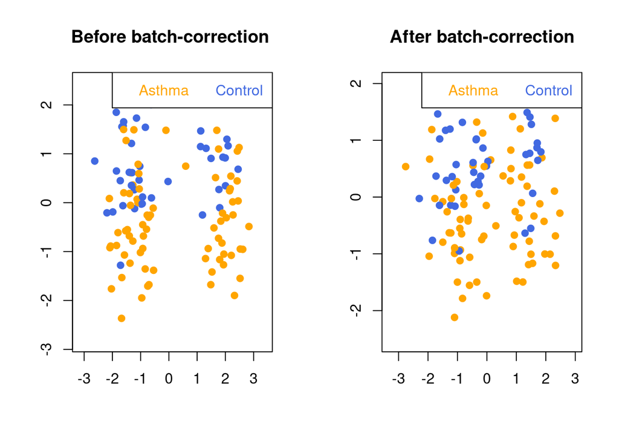

```r
# check MDS before and after batch correction
    par(mfrow=c(1,2))
    mdsPlot(dat =bVals , numPositions = 1000, sampNames = NULL, sampGroups = samples$Sample_Group,
          pch = 19, pal = col1,
          legendPos ="topright",
          main = "Before batch-correction ")

    mdsPlot(dat =bVals.corrected , numPositions = 1000, sampNames = NULL, sampGroups= samples$Sample_Group,
          pch = 19, pal = col1,
          legendPos ="topright",
          main = "After batch-correction")
```

Question 9: What does MDS before and after batch correction tells you?

## 2.11 CELL TYPE DECONVOLUTION

Here we infer the relative proportion of a priori known cell-types (i.e. Epithelial cells, liver cells, or blood immune cells : lymphocytes, monocytes, B-cells, and neutrophils) present within a sample representing a mixture of such cell types.

It is a modified version of [Houseman](https://bmcbioinformatics.biomedcentral.com/articles/10.1186/1471-2105-13-86) et al. (2012) regression calibration approach for deconvoluting heterogeneous tissue sources like blood. We have used here HEpiDISH function from [EpiDISH](https://bioconductor.org/packages/release/bioc/vignettes/EpiDISH/inst/doc/EpiDISH.htm) package in R.

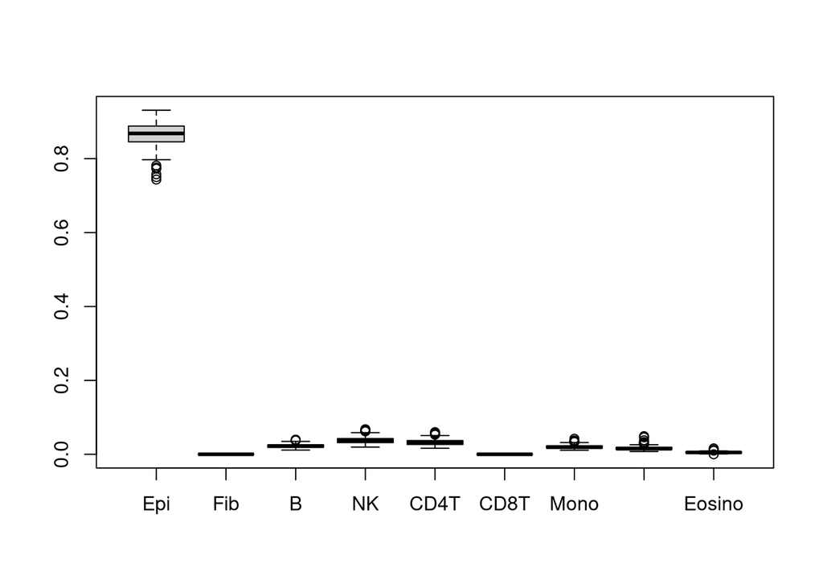

```r
data("centDHSbloodDMC.m")

frac.m <- hepidish(beta.m = bVals.corrected, ref1.m = centEpiFibIC.m, ref2.m = centBloodSub.m[,c(1,2,3,4,5,6,7)], h.CT.idx = 3, method = 'RPC')

# create a box plot to visualize the cell type proportions
boxplot(frac.m)
```

```r
# save the result
write.table(frac.m ,"Results/Tables/Cell_type_propotions_epidish.csv",
              sep = ",",
              quote = F,
              row.names = T)
```

Plot cell type distribution for each sample

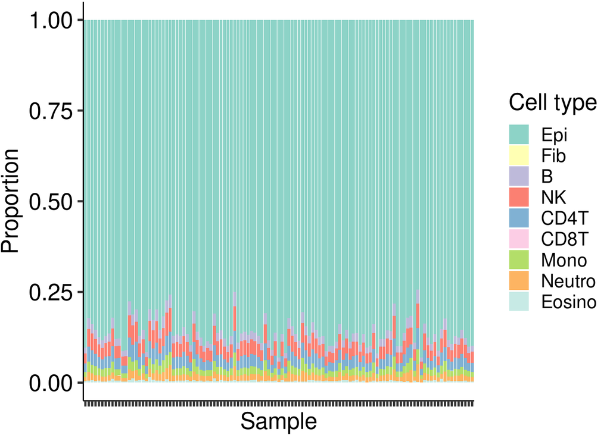

```r
pal = c('#8dd3c7','#ffffb3','#bebada','#fb8072','#80b1d3','#fccde5','#b3de69','#fdb462','#c7eae5','#d9d9d9','#dfc27d','#01665e')

mixAny <- reshape2::melt(frac.m)
colnames(mixAny) <- c("sample","cell","proportion")
p2 <- ggplot(mixAny, aes(x = sample, fill = cell)) +
  geom_bar(aes(weight = proportion)) +
  labs(x = "Sample", y = "Proportion", fill = "Cell type") +
  scale_x_discrete(breaks = waiver(), labels = NULL)+
  #scale_x_discrete(breaks = waiver(), labels = NULL)+
  theme_pubr(base_size = 19, margin = FALSE,legend="right")+
  scale_fill_manual(values = pal)
p2<-p2+ theme(axis.text.x = element_text(angle = 90))
p2
```

Question 10: What cell type is most abundant in the given dataset ? Is there any differences between the groups? Is there any outlier sample that has different distribution ?

## 2.12 DIFFERENTIAL METHYLATION

The **biological question** of interest for this particular dataset is to discover differentially methylated CpGs (DMCs) between the Asthma vs Control group.

- To do this, we will design a linear model in *limma* package (See manual for details). As previously seen, the sex contributed as significant source of variation and could be confounding factor in this analysis. Therefore, we will use sex as co-variate in the design matrix.
- Using the *topTable* function in limma, the differentially methylated genes per comparison/contrast can be extracted.

### 2.12.1 Differentially methylated CpGs (DMC)

```r
# Define the factor of interest i.e. Sample group with CFS vs non_CFS
  group <- factor(samples$Sample_Group)

# Define the confounding factor that need to be taken into account i.e sex
  sex <- factor(samples$Gender)
  smoker <- factor(samples$current_smoker)

# Design the matrix with group as our main variable of interest and sex as co-variate.
  design<-model.matrix(~0+group+sex+smoker,data=samples)

  colnames(design) <- c(levels(group),"sex","smoker")
  contMatrix <- makeContrasts(Asthma-Control,levels=design)

# fit the actual linear model to the data

# NOTE!! Here we are using beta value: bVals.corrected BUT mVals.corrected can be used.
  fit<-lmFit(bVals.corrected,design)
  colnames(fit$coefficients)
```

```
## [1] "Asthma"  "Control" "sex"     "smoker"
```

```r
  rownames(contMatrix)
```

```
## [1] "Asthma"  "Control" "sex"     "smoker"
```

```r
  fit2 <- contrasts.fit(fit, contMatrix)
  fit2 <- eBayes(fit2)
  summary(decideTests(fit2))
```

```
##        Asthma - Control
## Down               8672
## NotSig           404555
## Up                15027
```

```r
  # Annotate the DMCs using cleaned annotation object loaded above
  annot_combat <- annot[match(rownames(bVals.corrected),annot$CpG_ID),
                               c(1:ncol(annot))]
  # DMC full set
  DMCs<-topTable(fit2,coef = 1,number = Inf,genelist = annot_combat)

  # top DMCs based on FDR adj.P.Val < 0.05 cutoff and logFC > 0.1
  # You can adjust the cutoffs based on given datasets

  topset1<-subset(DMCs, DMCs$adj.P.Val<0.05 & abs(DMCs$logFC)>0.1)
  dim(topset1)
```

```
## [1] 45 12
```

```r
 # Check the name of top DMC and genes
 head(topset1[,c("CpG_ID","Relation_to_Island","Gene_Symbol","Gene_Accession","Gene_Group",       "Entrez_ID","logFC","P.Value","adj.P.Val" )])
```

```
##                CpG_ID Relation_to_Island Gene_Symbol      Gene_Accession
## cg20434422 cg20434422            OpenSea         UOX           NR_003927
## cg05075579 cg05075579            OpenSea       SORL1           NM_003105
## cg00393985       <NA>               <NA>        <NA>                <NA>
## cg13570892 cg13570892            OpenSea       DUOX1 NM_175940;NM_017434
## cg03002688 cg03002688            OpenSea        <NA>                <NA>
## cg03875819 cg03875819            OpenSea        <NA>                <NA>
##            Gene_Group Entrez_ID      logFC      P.Value    adj.P.Val
## cg20434422       Body    391051 -0.1182788 6.849606e-12 1.356529e-06
## cg05075579       Body      6653 -0.1038900 3.625002e-11 2.466433e-06
## cg00393985       <NA>        NA  0.1301780 4.464314e-11 2.466433e-06
## cg13570892  Body;Body     53905 -0.1209628 5.795154e-11 2.757553e-06
## cg03002688       <NA>        NA -0.1247345 7.997220e-11 3.113492e-06
## cg03875819       <NA>        NA -0.1579183 1.475133e-10 3.716069e-06
```

```r
 head(topset1)
```

```
##                CpG_ID Relation_to_Island Gene_Symbol      Gene_Accession
## cg20434422 cg20434422            OpenSea         UOX           NR_003927
## cg05075579 cg05075579            OpenSea       SORL1           NM_003105
## cg00393985       <NA>               <NA>        <NA>                <NA>
## cg13570892 cg13570892            OpenSea       DUOX1 NM_175940;NM_017434
## cg03002688 cg03002688            OpenSea        <NA>                <NA>
## cg03875819 cg03875819            OpenSea        <NA>                <NA>
##            Gene_Group Entrez_ID      logFC   AveExpr         t      P.Value
## cg20434422       Body    391051 -0.1182788 0.4692371 -7.664091 6.849606e-12
## cg05075579       Body      6653 -0.1038900 0.4757574 -7.336494 3.625002e-11
## cg00393985       <NA>        NA  0.1301780 0.5990357  7.295233 4.464314e-11
## cg13570892  Body;Body     53905 -0.1209628 0.6574884 -7.243434 5.795154e-11
## cg03002688       <NA>        NA -0.1247345 0.6042463 -7.179322 7.997220e-11
## cg03875819       <NA>        NA -0.1579183 0.4564338 -7.056910 1.475133e-10
##               adj.P.Val        B
## cg20434422 1.356529e-06 15.33550
## cg05075579 2.466433e-06 13.68344
## cg00393985 2.466433e-06 13.47712
## cg13570892 2.757553e-06 13.21869
## cg03002688 3.113492e-06 12.89978
## cg03875819 3.716069e-06 12.29381
```

Boxplot of the top CpG site

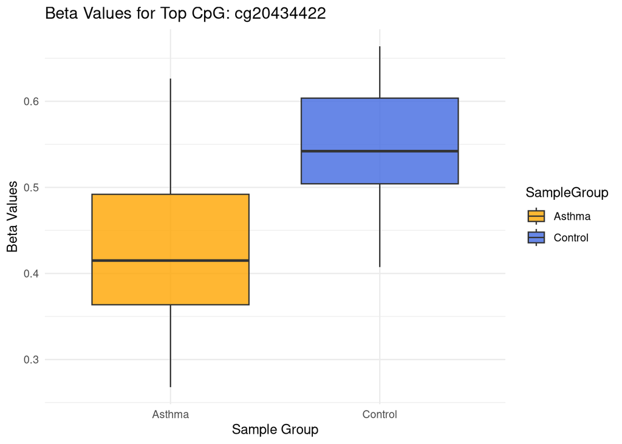

```r
top_cpg <- topset1$CpG_ID[1]

# Prepare data for ggplot
library(ggplot2)

plot_data <- data.frame(
  BetaValues = as.numeric(bVals.corrected[top_cpg, ]), # Extract beta values for the CpG
  SampleGroup = samples$Sample_Group                   # Add sample group information
)

# Plot using ggplot
ggplot(plot_data, aes(x = SampleGroup, y = BetaValues, fill = SampleGroup)) +
  geom_boxplot(alpha=0.8) +
  scale_fill_manual(values = col1) + # Custom colors
  labs(
    title = paste("Beta Values for Top CpG:", top_cpg),
    x = "Sample Group",
    y = "Beta Values"
  ) +
  theme_minimal()
```

Question 11: How many DMC pass the FDR adj.P.Val < 0.05 and nominal P.Value<0.05 ?

Question 12: What are the top 5 DMCs - provide CpG names? Which genes are affected - DMGs? Is there anything known about these genes and the Asthma ?

### 2.12.2 Volcano plot

Something you learned earlier

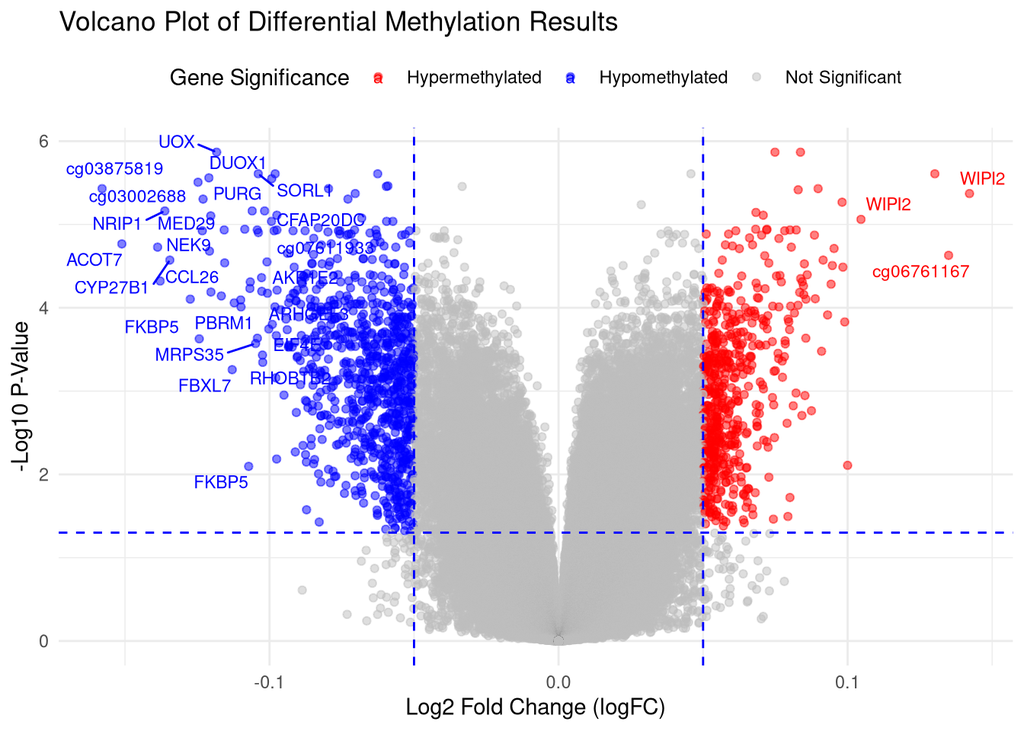

```r
annot[] <- lapply(annot, as.character)
#colnames(annot)

# store DMCs in results object
res <- DMCs

  res$label <- ifelse(!is.na(res$Gene_Symbol), res$Gene_Symbol, res$CpG_ID)

res$significance <- ifelse(res$adj.P.Val < 0.05 & res$logFC > 0.05, "Hypermethylated",
                                    ifelse(res$adj.P.Val < 0.05 & res$logFC < -0.05, "Hypomethylated", "Not Significant"))

# Order topTable_res by adjusted p-value
res <- res[order(res$adj.P.Val), ]

# Create the volcano plot
volcano_plot <- ggplot(res, aes(x = logFC, y = -log10(adj.P.Val), color = significance)) +
  geom_point(alpha = 0.5) +  # Scatter plot with transparency to see point density
  scale_color_manual(values = c("Not Significant" = "gray", "Hypermethylated" = "red", "Hypomethylated" = "blue")) +  # Set custom colors
  geom_hline(yintercept = -log10(0.05), linetype = "dashed", color = "blue") +  # Line indicating p-value threshold
  geom_vline(xintercept = c(-0.05, 0.05), linetype = "dashed", color = "blue") +  # Lines indicating logFC thresholds
  labs(title = "Volcano Plot of Differential Methylation Results",
       x = "Log2 Fold Change (logFC)",
       y = "-Log10 P-Value",
       color = "Gene Significance") +
  theme_minimal() +  # Clean plot theme
  theme(legend.position = "top")

# Add labels to the most significant genes using gene symbols (or Ensembl IDs if symbols are not available)
volcano_plot <- volcano_plot +
  geom_text_repel(data = subset(res, adj.P.Val < 0.01 & abs(logFC) > 0.1),
                  aes(label = label),  # Use the label column which contains either gene symbols or Ensembl IDs
                  size = 3, max.overlaps = 10)

# Print the volcano plot
print(volcano_plot)
```

## 2.13 PATHWAY ENRICHMENT ANALYSIS

After we have performed differential methylation analysis, we get long list of significant CpG sites to interpret. One important question is, “which gene pathways are over-represented for differentially methylated CpGs?” Sometimes, it can be easy to link the top DMCs to genes that make biological sense in terms of the cell types or samples being studied, but there may be many thousands of CpGs significantly differentially methylated. In order to gain an understanding of the biological processes that the differentially methylated CpGs may be involved in, we can perform gene ontology or KEGG pathway analysis using the *gometh* function in the [missMethyl](https://academic.oup.com/bioinformatics/article/32/2/286/1744111) package.

### 2.13.1 Gene Ontology

The *gometh* takes into account the varying numbers of CpGs associated with each gene on the Illumina methylation arrays. The top 20 gene ontology categories can be displayed using the topGO function. For KEGG pathway analysis, the topKEGG function can be called to display the top 20 enriched pathways.

```r
# Get the significant CpG sites at less than 5% FDR, or use nominal p-values
sigCpGs <- DMCs$CpG_ID[DMCs$adj.P.Val<0.05]

# First 10 significant CpGs
sigCpGs[1:10]
```

```
##  [1] "cg18198301" "cg20434422" "cg27456951" "cg02193283" "cg05075579"
##  [6] "cg13017929" NA           "cg24707200" "cg13570892" "cg08271907"
```

```r
# Total number of significant CpGs at 5% FDR
length(sigCpGs)
```

```
## [1] 23699
```

```r
# Get all the CpG sites used in the analysis to form the background
all <- DMCs$CpG_ID

# Total number of CpG sites tested
length(all)
```

```
## [1] 428254
```

```r
# The gst object is a data.frame with each row corresponding to the GO category being tested
gst <- gometh(sig.cpg=sigCpGs, all.cpg = all, plot.bias=FALSE)

# Top 10 gene sets, GO categories
topGSA(gst, number=10)
```

```
##            ONTOLOGY                               TERM    N   DE         P.DE
## GO:0071944       CC                     cell periphery 5658 2665 7.224749e-30
## GO:0005886       CC                    plasma membrane 5198 2441 3.457731e-26
## GO:0032501       BP   multicellular organismal process 7022 3179 2.059836e-19
## GO:0009653       BP anatomical structure morphogenesis 2657 1384 9.201359e-17
## GO:0030054       CC                      cell junction 2270 1201 3.883439e-15
## GO:0007154       BP                 cell communication 6198 2793 3.978195e-15
## GO:0023052       BP                          signaling 6172 2780 4.754052e-15
## GO:0003008       BP                     system process 2167 1027 1.692023e-14
## GO:0030182       BP             neuron differentiation 1378  777 1.697544e-14
## GO:0048699       BP              generation of neurons 1460  815 5.633839e-14
##                     FDR
## GO:0071944 1.608879e-25
## GO:0005886 3.850011e-22
## GO:0032501 1.529016e-15
## GO:0009653 5.122626e-13
## GO:0030054 1.476507e-11
## GO:0007154 1.476507e-11
## GO:0023052 1.512400e-11
## GO:0003008 4.200289e-11
## GO:0030182 4.200289e-11
## GO:0048699 1.254600e-10
```

Visualization of GO enrichment plot

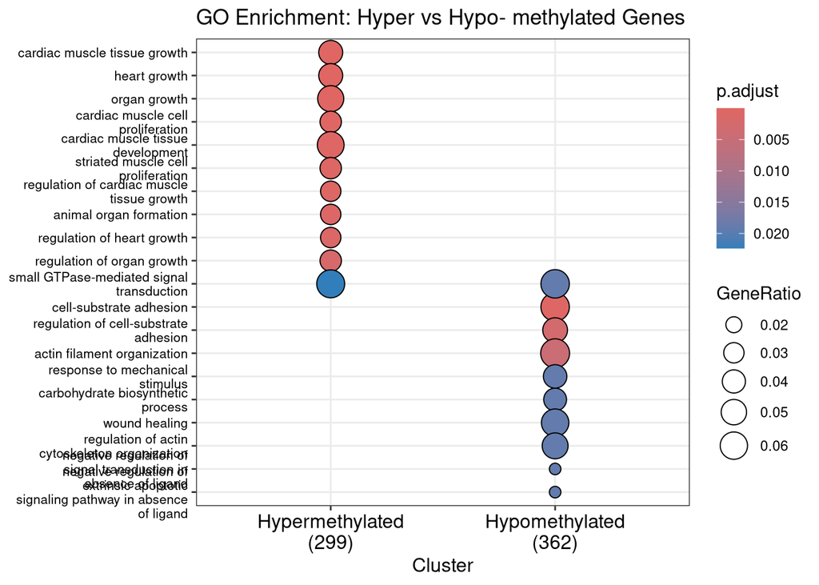

```r
# Extract Hyper genes (based on significance column)
Hyper <- res[res$significance == "Hypermethylated", ]

# Extract down-regulated genes (based on significance column)
Hypo <- res[res$significance == "Hypomethylated", ]


# Put the hyper- and hypo gene groups in a named list
GeneClust <- list("Hypermethylated" = Hyper$Entrez_ID, "Hypomethylated" = Hypo$Entrez_ID)

# Run GO enrichment analysis to compare the two groups, focusing on biological processes (BP)
geores <- compareCluster(
  geneClusters = GeneClust,          # List of gene clusters (up- and down-regulated)
  fun = "enrichGO",                  # Enrichment function (GO enrichment)
  OrgDb = org.Hs.eg.db,              # Human gene annotation database
  keyType = "ENTREZID",               # Specify that Ensembl IDs are used
  ont = "BP",                        # Ontology: Biological Process
  pAdjustMethod = "BH",              # Adjust p-values using Benjamini-Hochberg method
  pvalueCutoff = 0.05,               # Set p-value cutoff
  qvalueCutoff = 0.05                # Set q-value cutoff
)

# Visualize the enrichment results in a dot plot
dotplot(geores, showCategory = 10, title = "GO Enrichment: Hyper vs Hypo- methylated Genes") +
  theme(axis.text.y = element_text(size = 8))
```

### 2.13.2 KEGG enrichment

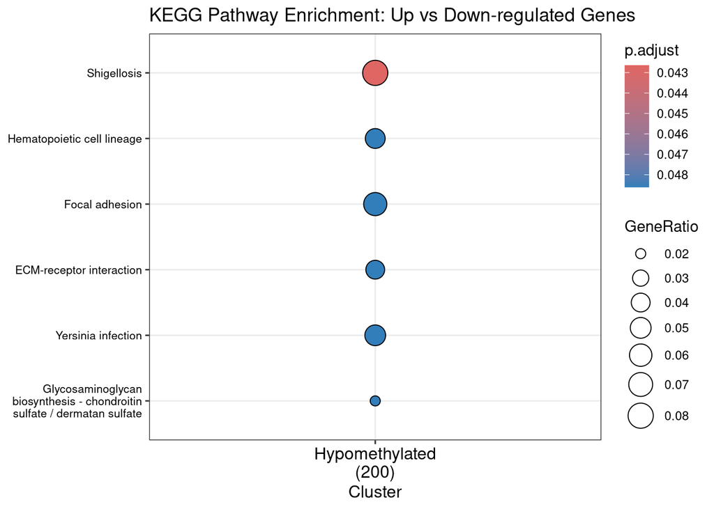

```r
# Extract Hyper genes (based on significance column)
Hyper <- res[res$significance == "Hypermethylated", ]

# Extract down-regulated genes (based on significance column)
Hypo <- res[res$significance == "Hypomethylated", ]


# Put the hyper- and hypo gene groups in a named list
GeneClust <- list("Hypermethylated" = Hyper$Entrez_ID, "Hypomethylated" = Hypo$Entrez_ID)

# Run KEGG enrichment analysis to compare the two groups using ENTREZ IDs
kegg_res <- compareCluster(
  geneClusters = GeneClust,          # List of gene clusters (up- and down-regulated)
  fun = "enrichKEGG",                # KEGG pathway enrichment function
  organism = "hsa",                  # Human organism ('hsa' for Homo sapiens)
  pAdjustMethod = "BH",              # Adjust p-values using Benjamini-Hochberg method
  pvalueCutoff = 0.05,               # Set p-value cutoff
  qvalueCutoff = 0.1                # Set q-value cutoff
)

# Check if there are any results
if (is.null(kegg_res) || nrow(as.data.frame(kegg_res)) == 0) {
  print("No significant KEGG pathways were found.")
} else {
  # Visualize the KEGG enrichment results in a dot plot
  dotplot(kegg_res, showCategory = 10, title = "KEGG Pathway Enrichment: Up vs Down-regulated Genes") +
    theme(axis.text.y = element_text(size = 8))
}
```

Question 13: What are top KEGG and GO enrichment results ?

# 3 ASSIGNMENT4

> **Research Question**: Is there significant differences in DNA methylation states in Asthma phenotype compared to control samples?  
> **Reflection**: Reflect on your analysis and what you find. In this tutorial, you find questions (Q1-Q13). These questions are meant for you to reflect on and understand important/key points. The questions must be answered in the report.  
> **Report**: The report must be an HTML format (Rmarkdown) and must include all the steps you did, the results, and your interpretations of the steps and/or results.  
> **Dataset**: Samples collected from epithelial airway cells 115 individuals. Use the same datasets as the hands-on for the this assignment.